# Data Analysis Report 2

Will Kramlinger

January 20, 2019

## Introduction

The adequacy of a prescribed linear model for a simulated data set comprising sales of child car seats and associated predictors was analyzed. Given this model, the data set was subject to residual analyses intended to identify possible influential points, detect and repair any instances of multicollinearity, and gauge the need for variable transformations.

The analysis is guided heavily by two example labs provided by Professor Talih, as well as a model building strategy outlined in the STAT 501 Online Notes: https://newonlinecourses.science.psu.edu/stat501/node/335/.

## Data

The data set analyzed was the **Carseats** data set included in the R package **ISLR**. The set includes observations for sales of child car seats at 400 different stores and 10 predictors. The predictors included continuous variables **CompPrice**, **Income**, **Advertising**, **Population**, **Price**, **Age**, and **Education**. Categorical predictors were **ShelveLoc**, **Urban**, and **US**.

For variable definitions, please refer to https://www.rdocumentation.org/packages/ISLR/versions/1.2/topics/Carseats. The following shall presume the reader’s familarity with the variable names and their meanings, as they are used interchangeably. A check for missing data within the set revealed no problems.

The aforementioned variable **ShelveLoc** was found to be a categorical variable with 3 possible levels: “Bad”, “Medium”, and “Good”. The variable was then re-coded by splitting into two new variables, **ShelveLocMedium** and **ShelveLocGood**, where **ShelveLocMedium** = 1 if “Medium” and 0 otherwise; **ShelveLocGood** = 1 if “Good” and 0 otherwise. The response “Bad” thus became the reference level. The other categorical (binary) variables, **Urban** and **US** were also re-coded as 1 for a “Yes”, and 0 for “No” for ease of visualization and interpretation. Histograms for all variables are shown as Fig. 1.

## Analyses

*-LINE Assumptions*

*-Outliers, High Leverages, and Influential Points*

The residuals were more closely examined to investigate potential outliers. Based on Prof. Talih’s guidance, the criterion used to flag potential outliers was to flag if the absolute value of the residual exceeded 3 times the residual standard error (*s* = 1). Based on this criterion, observation 358 (*e* = 3.41) was noted as an outlier and a possible influential point.

Evaluation of potential influential points was conducted based on examination of Cook’s distances, *d*, using a criterion of: if *d* > 1, then influential.  
Application of this criterion yielded no influential points; the maximum value found was *d* = 0.0304 (observation 357). Because of these findings, **the decision was made to continue without removing any data points**.

*-Multicollinearity*

Scatterplot and correlation matrices were generated to investigate potential collinearity between predictors, though only correlation values between continuous predictors were considered. Visual inspection of the scatterplot matrix provided two signs of possible collinearity amongst the predictors. **CompPrice** and **Price** were non-trivially positively correlated via plot; however, the correlation value of *r* = 0.585 did not raise much concern. Also, a plot of **Advertising** vs. **US** revealed a statistically significant difference in mean advertising budgets between non-US and US stores at 95% confidence; the average advertising budget in US stores was found to be between 8.73K and 10.28K greater than those outside of the US. Plots of these 2 pairs of variables are shown as Fig. 4.

As a final check for multicollinearity, simple linear regression (SLR) models were generated for **Sales** regressed on each one of the predictors. Coefficients, standard errors, and test statistics were compared to those from *full.model*. Significant differences between *full.model* and each respective variable’s SLR model were found for **CompPrice**, **Price**, **ShelveLocMedium**, **Urban**, and **US** in terms of regression coefficients. Additionally, the significance of the predictors, at 95% confidence, differed for **CompPrice**, **ShelveLocMedium** (significant in *full.model*, not in SLR), and **US** (significant in SLR, not in *full.model*).

*-Variable Selection and Model Refinement*

Before elimination of variables, all possible two-way interaction effects were considered in a new model (hence *int.full.model*). At 95% confidence, only 2 significant interactions were found: **CompPrice:Income** and **Age:US**. Because they were not found to be significant in *full.model*, nor in their own SLR models, nor the current *int.full.model*, the predictors **Population**, **Education**, and **Urban** were eliminated from the model as they were found to be extraneous variables.

Best subsets regression was carried out using both the Mallows $C_p$ and BIC criteria, which suggested that the optimal number of predictors was 7 and that **US** should be omitted from the final model, which correlates with the previous discussion above concerning the instability of the **US** coefficient. Interactions were explored to little success. A candidate model (*trimmed.model*) thus emerged with **CompPrice**, **Income**, **Advertising**, **Price**, **ShelveLocMedium**, **ShelveLocGood**, and **Age** as predictors.

The selected model was *price.diff.model* due to the improvements observed in the reduction in the VIFs and standard errors of the coefficients. The chosen model is  
$Sales = 5.113 - 0.095(PriceDiff) + 0.016(Income) + 0.116(Advertising)$ $+ 1.949(ShelveLocMedium) + 4.831(ShelveLocGood) - 0.046(Age)$.

## Plots and Tables

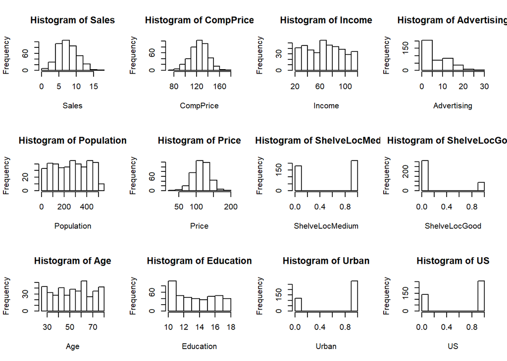

Fig. 1: Histograms for the variables in the Carseats data set with slightly modified variables

Table 1: Summary of linear model *(full.model)* for variable **Sales** regressed on 11 predictors. Results reveal **CompPrice**, **Income**, **Advertising**, **Price**, **ShelveLocMedium**, **ShelveLocGood**, and **Age** are significant linear predictors of **Sales** given the presence of all other predictors.

```
##
## Call:
## lm(formula = df$Sales ~ ., data = df)
##
## Residuals:
##    Min     1Q Median     3Q    Max
## -2.869 -0.691  0.021  0.664  3.411
##
## Coefficients:
##                  Estimate Std. Error t value Pr(>|t|)
## (Intercept)      5.660623   0.603449    9.38  < 2e-16 ***
## CompPrice        0.092815   0.004148   22.38  < 2e-16 ***
## Income           0.015803   0.001845    8.56  2.6e-16 ***
## Advertising      0.123095   0.011124   11.07  < 2e-16 ***
## Population       0.000208   0.000370    0.56     0.58
## Price           -0.095358   0.002671  -35.70  < 2e-16 ***
## ShelveLocMedium  1.956715   0.126106   15.52  < 2e-16 ***
## ShelveLocGood    4.850183   0.153110   31.68  < 2e-16 ***
## Age             -0.046045   0.003182  -14.47  < 2e-16 ***
## Education       -0.021102   0.019720   -1.07     0.29
## Urban            0.122886   0.112976    1.09     0.28
## US              -0.184093   0.149842   -1.23     0.22
## ---
## Signif. codes:  0 '***' 0.001 '**' 0.01 '*' 0.05 '.' 0.1 ' ' 1
##
## Residual standard error: 1.02 on 388 degrees of freedom
## Multiple R-squared:  0.873,  Adjusted R-squared:  0.87
## F-statistic:  243 on 11 and 388 DF,  p-value: <2e-16
```

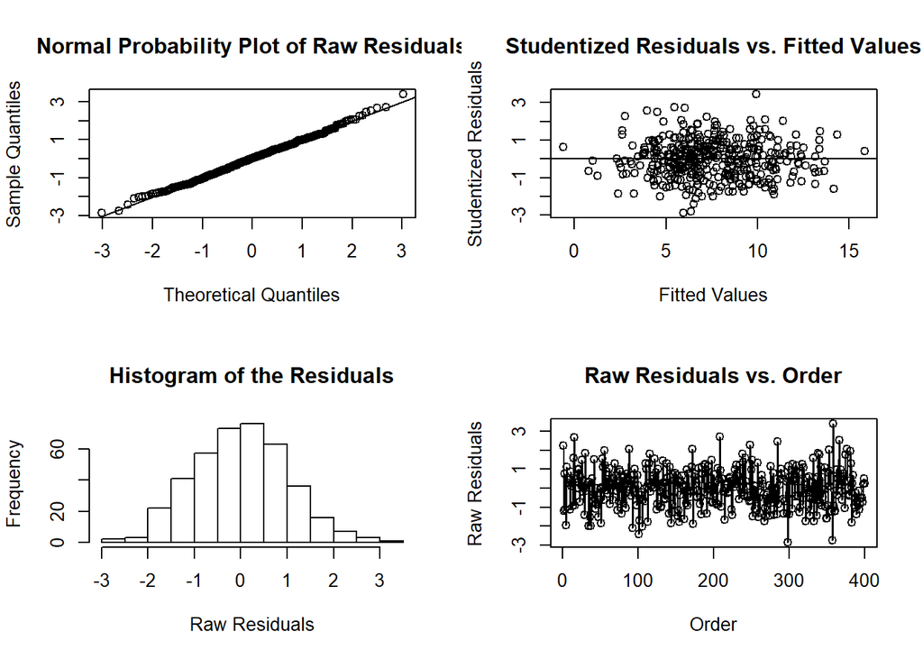

Fig. 2: Residual diagnostic plots for *full.model*. The plots all indicate the validity of the LINE assumptions for applying regression to this data set, and did not suggest mandatory variable transformations. Plots for subsequent models remained similarly well-behaved.

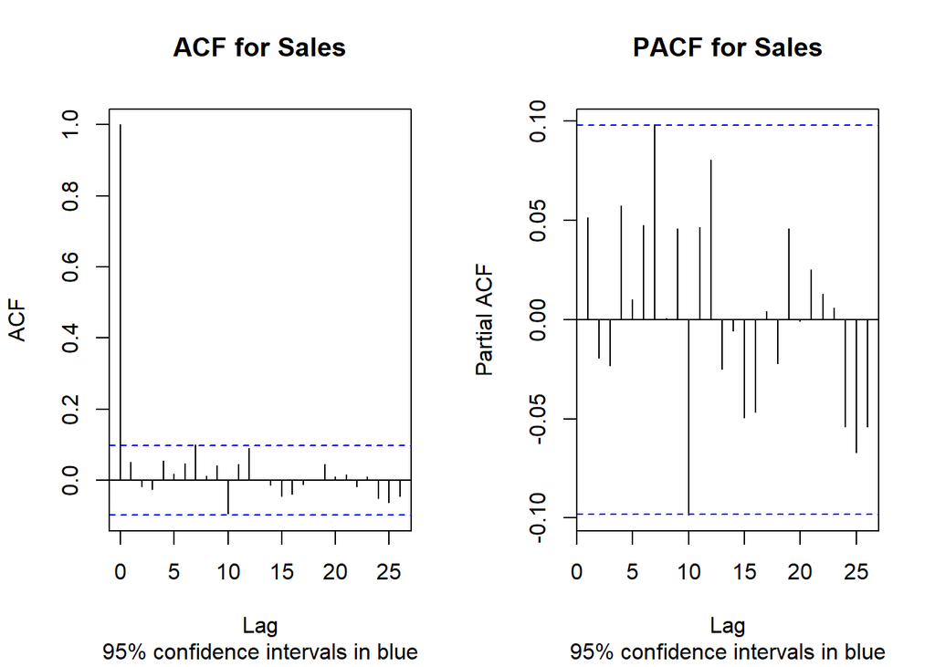

Fig 3: ACF and PACF vs. Lag plots for **Sales**. The plots corroborate the residuals vs. order plot in Fig. 2 in suggesting no violation of the independent residuals assumption.

Table 2: Regression output for *full.model* without 3 points flagged as possibly influential. Upon comparison with Table 1, there are minor differences save for evidence of possible instability in the **US** coefficient.

```
##
## Call:
## lm(formula = infl.df$Sales ~ ., data = infl.df)
##
## Residuals:
##     Min      1Q  Median      3Q     Max
## -2.8930 -0.7107  0.0312  0.6606  2.7283
##
## Coefficients:
##                  Estimate Std. Error t value Pr(>|t|)
## (Intercept)      5.553898   0.605528    9.17   <2e-16 ***
## CompPrice        0.093421   0.004155   22.48   <2e-16 ***
## Income           0.015805   0.001823    8.67   <2e-16 ***
## Advertising      0.127480   0.011254   11.33   <2e-16 ***
## Population       0.000160   0.000367    0.44     0.66
## Price           -0.094899   0.002667  -35.58   <2e-16 ***
## ShelveLocMedium  1.937341   0.124961   15.50   <2e-16 ***
## ShelveLocGood    4.844069   0.151352   32.01   <2e-16 ***
## Age             -0.045239   0.003157  -14.33   <2e-16 ***
## Education       -0.023119   0.019573   -1.18     0.24
## Urban            0.108845   0.111915    0.97     0.33
## US              -0.242974   0.149844   -1.62     0.11
## ---
## Signif. codes:  0 '***' 0.001 '**' 0.01 '*' 0.05 '.' 0.1 ' ' 1
##
## Residual standard error: 1.01 on 385 degrees of freedom
## Multiple R-squared:  0.875,  Adjusted R-squared:  0.872
## F-statistic:  246 on 11 and 385 DF,  p-value: <2e-16
```

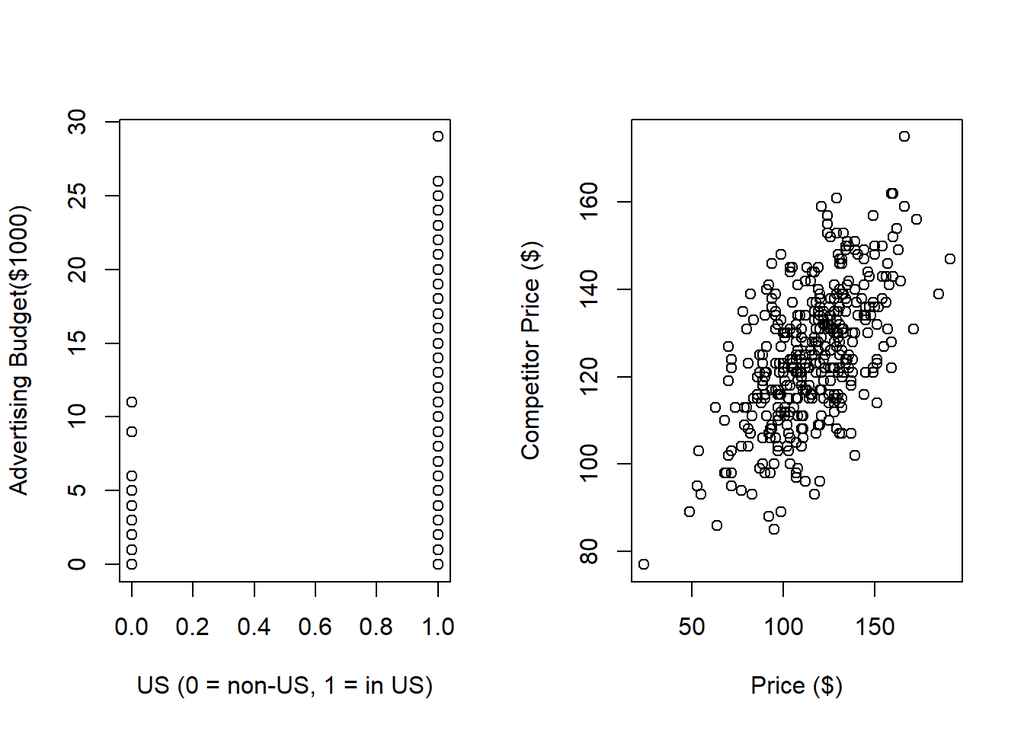

Fig. 4: Plots of **Advertising** vs. **US** and **CompPrice** vs. **Price**. After inspecting correlation and scatterplot matrices, these two variable pairs raised most concerns about collinearity and/or redundant variables.

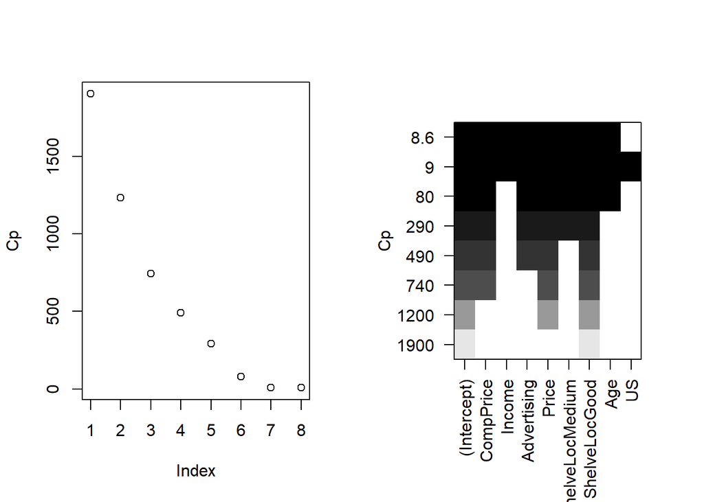

Fig.5: Plots of $Cp$ vs. *p* and $C_p$ vs. Predictors Included for *trimmed.model*. Plots used for best subsets regression and suggest the inclusion of 7 non-intercept predictors.

Table 3: Regression output for *price.diff.model* which was chosen as the final model.

```
##
## Call:
## lm(formula = price.diff.df$Sales ~ . - Population - Education -
##     Urban - US, data = price.diff.df)
##
## Residuals:
##    Min     1Q Median     3Q    Max
## -2.764 -0.695  0.027  0.676  3.399
##
## Coefficients:
##                 Estimate Std. Error t value Pr(>|t|)
## (Intercept)      5.11286    0.23942   21.36   <2e-16 ***
## PriceDiff       -0.09514    0.00266  -35.77   <2e-16 ***
## Income           0.01590    0.00183    8.68   <2e-16 ***
## Advertising      0.11601    0.00772   15.03   <2e-16 ***
## ShelveLocMedium  1.94892    0.12526   15.56   <2e-16 ***
## ShelveLocGood    4.83078    0.15232   31.72   <2e-16 ***
## Age             -0.04585    0.00316  -14.52   <2e-16 ***
## ---
## Signif. codes:  0 '***' 0.001 '**' 0.01 '*' 0.05 '.' 0.1 ' ' 1
##
## Residual standard error: 1.02 on 393 degrees of freedom
## Multiple R-squared:  0.872,  Adjusted R-squared:  0.87
## F-statistic:  445 on 6 and 393 DF,  p-value: <2e-16
```

## Conclusions

A simulated data set comprising carseat sales at 400 different stores along with 10 predictors (7 continuous, 3 categorical) was analyzed for influential points, multicollinearity, and necessary variable transformations. The set had no missing values but required a re-coding of a predictor with 3 levels. Residual analysis suggested that the LINE assumptions were satisfied, no data transformations were drastically needed, and also revealed a few possible outliers. Leverages and Cook’s distances were calculated to investigate influential points; based on these calculations, the decision was made to not eliminate any observations. Collinearity amongst the predictors was investigated via scatterplot and correlation matrices, VIFs, and condition numbers; no severe violations were found. Pairwise interactions were investigated to eliminate extraneous variables. Candidate models were evaluated via best subsets regression based on $C_p$ and BIC while also monitoring coefficient stability and VIF. The final model chosen included 6 predictors and included no interactions: **PriceDiff**, **Income**, **Advertising**, **ShelveLocMedium**, **ShelveLocGood**, and **Age**.

## Appendix I: R Code

The following code has not been edited for cleanliness and supplements that which is found in the Plots and Tables section.

```r
which(is.na(df) == TRUE) # Locates missing values, if any; returned 0 (NULL)
```

```r
length(which(df$Urban == 1)) / 400 ## 282/400 = 70.5% are Urban
length(which(df$US == 1)) / 400 ## 258/400 = 64.5% are US
```

```r
t.test(df$Advertising[df$US == 1], df$Advertising[df$US == 0] )
```

```
##
##  Welch Two Sample t-test
##
## data:  df$Advertising[df$US == 1] and df$Advertising[df$US == 0]
## t = 24, df = 320, p-value <2e-16
## alternative hypothesis: true difference in means is not equal to 0
## 95 percent confidence interval:
##   8.727 10.275
## sample estimates:
## mean of x mean of y
##    10.008     0.507
```

```r
# Significant differences between US and non-US advertisting budgets
```

```r
# Test for normality with Anderson-Darling
ad.test(full.model$residuals) # AD = 0.19, p-value = 0.9
# Test for equal variances with Breusch-Pagan
ols_test_breusch_pagan(full.model) # p-value = 0.7775
```

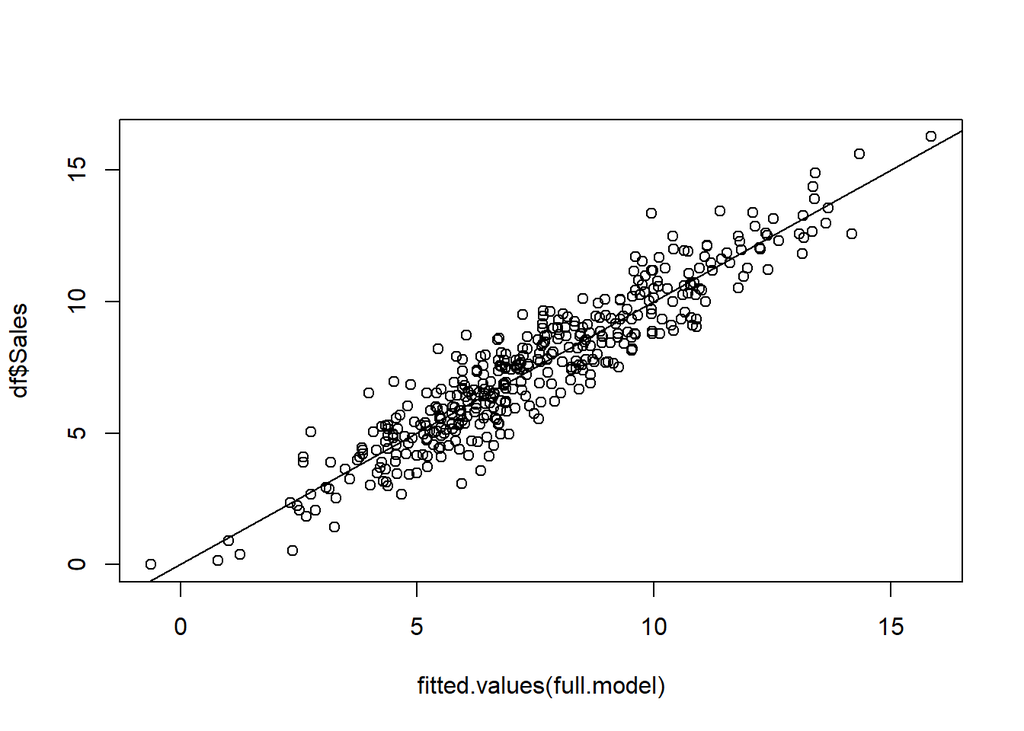

```r
## summary(full.model) # residual standard error = 1
## anova(full.model) # Reveals significant predictors include CompPrice, Income,
# Advertising, Price, ShelveLoc, and Age IN FULL MODEL
# Compare min and max residuals to 3 times the S.E.(res) as seen in example
plot.new()
min.res <- min(full.model[[2]])
max.res <- max(full.model[[2]])
abs(min.res) > 3; abs(max.res) > 3
which(abs(full.model$residuals) > 3) # Observation 358 may be outlier/influential

res.df <- data.frame(raw = resid(full.model), stud = rstudent(full.model))
## identify(fitted.values(full.model), rstudent(full.model),
##         labels = row.names(df)) # Observation 358 may be outlier/influential
outlierTest(full.model) # Confirms observation 358

# Check observations vs. fits
plot(fitted.values(full.model), df$Sales)
abline(a = 0, b = 1)
```

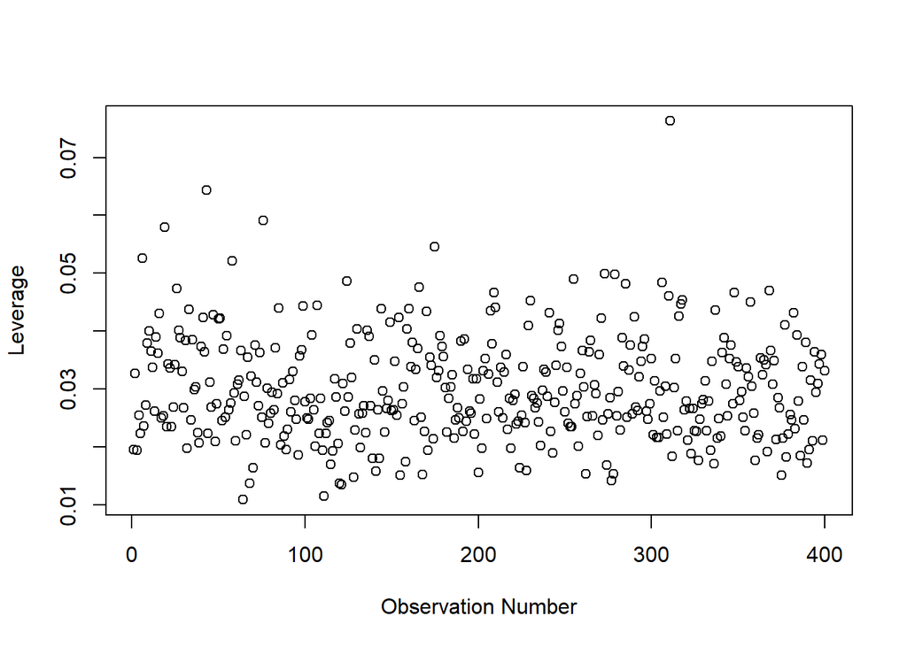

```r
# Investigate the predictor levels of observation 358
df[358,]  # No immediately concerning predictor levels

# Investigate high leverage points
res.df$lev <- hatvalues(full.model)
par(mfrow = c(1,1))
plot(res.df$lev, xlab = "Observation Number", ylab = "Leverage")
```

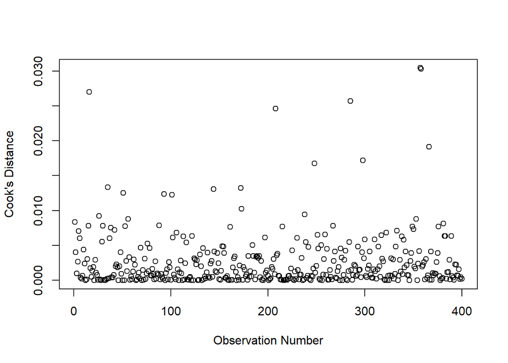

```r
## identify(res.df$lev)  # Observation 311 may be high leverage
lev.thresh <- 2 * sum(hatvalues(full.model)) / nrow(df)
which(hatvalues(full.model) > lev.thresh) # Returns observations 43, 311

# Investigate Cook's distances for influential points
res.df$cooks <- cooks.distance(full.model)
plot(res.df$cooks, xlab = "Observation Number", ylab = "Cook's Distance")
```

```r
which(res.df$cooks > 1) # Returns 0
```

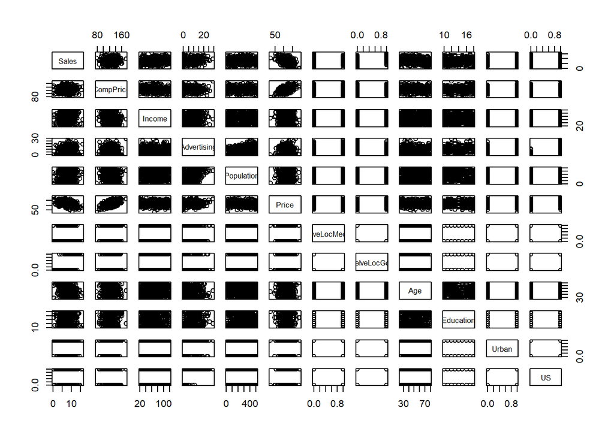

```r
# Check for multicollinearity amongst predictors
pairs(df) # Inspection of scatterplot matrix does not reveal obvious collinearity
```

```r
# in the data set, with the possible exception of CompPrice ~ Price
cor(df)
```

```r
vif(full.model)  # No VIFs exceed 5 (investigation warranted) nor 10 (fix
# immediately), as taught in STAT 501
# Try the condition number method as explained by Example 2
X <- model.matrix(full.model)
Z <- X[ , -1]
Z <- scale(Z)
M <- t(Z) %*% Z
eigen(M)
talih.cond.number <- max(eigen(M)$values) / min(eigen(M)$values)
wiki.cond.number <- sqrt(max(eigen(M)$values) / min(eigen(M)$values))
# Regardless of cond.number calculation, multicollinearity does not seem to
# be too much of a worry
```

```r
# Examine each SLR
slr.stats <- matrix(numeric(), nrow = 22, ncol = 4)
colnames(slr.stats) <- colnames(summary(full.model)$coefficients)
for (i in 1:11) {
  temp.model <- lm(df$Sales ~ df[ , (i + 1)] )
  slr.stats[(2*i - 1), ] <- summary(temp.model)$coefficients[1, ]
  slr.stats[2*i, ] <- summary(temp.model)$coefficients[2, ]}
slr.stats <- as.data.frame(slr.stats)
row.names(slr.stats)[2*(1:11) - 1] <- paste0(colnames(df)[2:12], " Intercept")
row.names(slr.stats)[2*(1:11)] <- colnames(df)[2:12]
round(slr.stats, 4)
# SLRs indicate that Income, Advertising, Price,
# ShelveLocGood, Age, and US are significant linear predictors IN SLR MODELS
### THIS DIFFERS FROM FULL MODEL: CompPrice, ShelveLocMedium are not included
### while US is included

### The variables which are not significant in both the full and SLR models are:
### Population, Education, and Urban.  Likely OK getting rid of these variables.
```

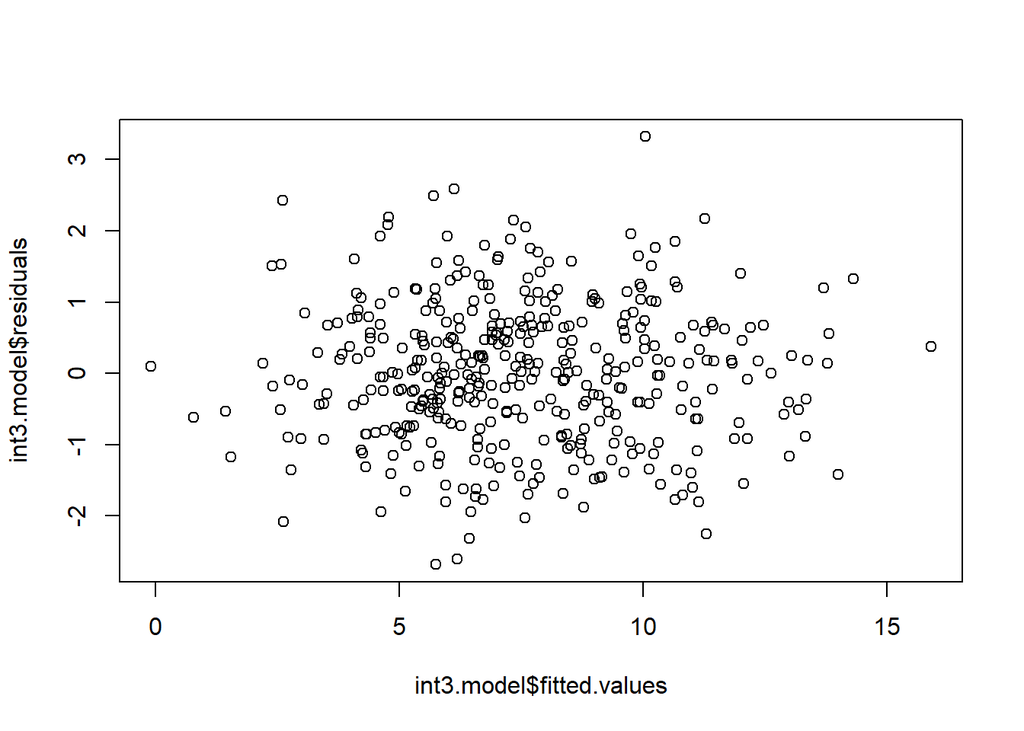

```r
# Screw around with interactions
int.full.model <- lm(df$Sales ~ .^2, data = df)
summary(int.full.model)
which(summary(int.full.model)$coefficients[ , 4] < 0.05) # Extracts p-values
# Indicates that CompPrice:Income and Age:numUS are significant interactions
anova(int.full.model)
# Generate new model with only those 2 interactions
int2.model <- lm(df$Sales ~ . + df$CompPrice:df$Income + df$Age:df$US,
                 data = df)
summary(int2.model);
summary(full.model)

round(summary(full.model)$coefficients, 3)
round(summary(int2.model)$coefficients, 3)

# Remove non-significant predictors from int2.model
int3.model <- lm(Sales ~ . + CompPrice:Income + Age:US -
                   Population - Education - Urban,
                 data = df)
round(summary(int3.model)$coefficients, 3)
summary(int3.model)
vif(int3.model) # Wayyyyyyyy too high
plot(int3.model$residuals ~ int3.model$fitted.values)
```

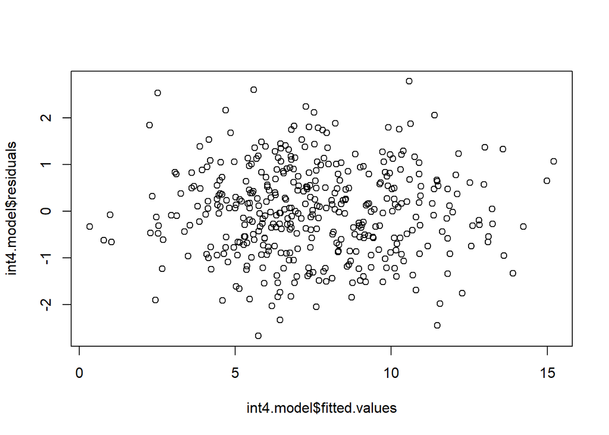

```r
# Remove US?
int4.model <- lm(Sales ~ .^2,
                 data = trimmed.df)
summary(int4.model)
plot(int4.model$residuals ~ int4.model$fitted.values)
```

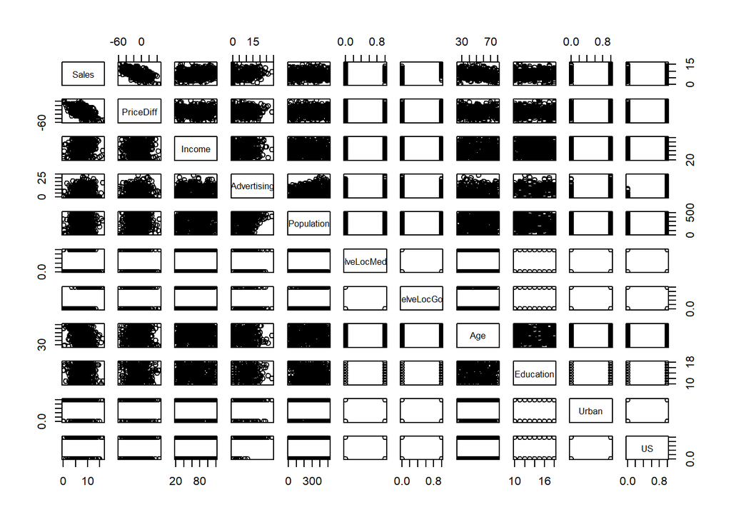

```r
summary(int4.model) # Still probably not a good idea.  Go back to int3.model.

price.diff.df <- df
price.diff.df$PriceDiff <- price.diff.df$Price - price.diff.df$CompPrice
price.diff.df <- price.diff.df[ , c(1, 13, 3:5, 7:12)]
price.diff.model <- lm(price.diff.df$Sales ~ ., data = price.diff.df)
pairs(price.diff.df)
```

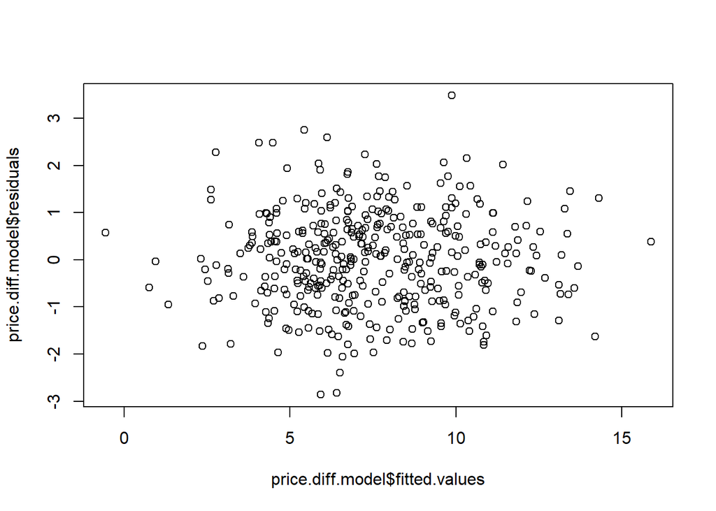

```r
summary(price.diff.model)
vif(price.diff.model)
vif(full.model)
par(mfrow = c(1,1))
plot(price.diff.model$residuals ~ price.diff.model$fitted.values)
```

```r
# Check out new price diff with trimmed variables
price.trimmed.df <- price.diff.df[ , c(1:4, 6:8, 11)]
price.trimmed.model <- lm(Sales ~ .,
                 data = price.trimmed.df)
summary(price.trimmed.model)
vif(price.trimmed.model) # Has US still in

# Check out interactions
price.trimmed.model2 <- lm(Sales ~ .^2, data = price.trimmed.df)
summary(price.trimmed.model2)
# Age:US, ShelveLocGood:US, Income:Advertising

# Check out interactions
price.trimmed.model3 <- lm(Sales ~ . + Age:US + ShelveLocGood:US +
                             Income:Advertising, data = price.trimmed.df)
summary(price.trimmed.model3)
vif(price.trimmed.model3) # Things get whacky!!!  Exclude int's except US:Shelve

price.trimmed.model4 <- lm(Sales ~ . + ShelveLocGood:US, data = price.trimmed.df)
summary(price.trimmed.model4)
vif(price.trimmed.model4) # Not bad...US:ShelveLocGood and ShelveLocGood are a bit high

price.trimmed.model5 <- lm(Sales ~ . - US, data = price.trimmed.df)
summary(price.trimmed.model5)
vif(price.trimmed.model5) # Pretty good without US.  Now try without ShelveLocGood

price.trimmed.model6 <- lm(Sales ~ . - ShelveLocGood, data = price.trimmed.df)
summary(price.trimmed.model6)
vif(price.trimmed.model6) # NO.  Need to leave ShelveLocGood in.

# Not PRICEDIFF
trimmed.df <- df[ , c(1:4, 6:9, 12)]
full.model.trimmed <- lm(Sales ~ ., data = trimmed.df)
summary(full.model.trimmed)
vif(full.model.trimmed)

full.model.trimmed2 <- lm(Sales ~ .^2, data = trimmed.df)
summary(full.model.trimmed2)

full.model.trimmed3 <- lm(Sales ~ ., data = trimmed.df)
summary(full.model.trimmed3)
vif(full.model.trimmed3)
# Got rid of Advertising:Price
```